# DES_part5_03694565

### 5.2 Simulation Study IV

```python
%matplotlib inline
from pylab import rcParams
rcParams['figure.figsize'] = (40,30)
```

```python
import part5_simstudy
```

#### Task 5.2.1: Multiple Runs Confidence

```python
part5_simstudy.task_5_2_1()
```

```
SIM TIME:  100s; ALPHA: 10%; NUMBER OF RUNS: 4216; TOTAL SIMULATION TIME (SECONDS): 421600; Blocking Probability Mean: 0.11611490311734823; Half width: 0.001499754888409052
SIM TIME:  100s; ALPHA:  5%; NUMBER OF RUNS: 6115; TOTAL SIMULATION TIME (SECONDS): 611500; Blocking Probability Mean: 0.11693715127686174; Half width: 0.0014999243898490202
SIM TIME: 1000s; ALPHA: 10%; NUMBER OF RUNS:  467; TOTAL SIMULATION TIME (SECONDS): 467000; Blocking Probability Mean: 0.12383783948713835; Half width: 0.0014998227615448014
SIM TIME: 1000s; ALPHA:  5%; NUMBER OF RUNS:  649; TOTAL SIMULATION TIME (SECONDS): 649000; Blocking Probability Mean: 0.12553924339293032; Half width: 0.0014995452279987376
```

```
[4216, 6115, 467, 649]
```

#### Task 5.2.2: Batch Confidence

```python
part5_simstudy.task_5_2_2()
```

```
BATCH SIZE:  100; ALPHA: 10%; TOTAL SIMULATION TIME (SECONDS): 459973.5866194854; Blocking Probability Mean: 0.12708541621386657; Half width: 0.0014998497089862032
BATCH SIZE:  100; ALPHA:  5%; TOTAL SIMULATION TIME (SECONDS): 677122.7322274013; Blocking Probability Mean: 0.12714433141677725; Half width: 0.00149984300380951
BATCH SIZE: 1000; ALPHA: 10%; TOTAL SIMULATION TIME (SECONDS): 466904.38957933907; Blocking Probability Mean: 0.12505781584582443; Half width: 0.0014999259412804482
BATCH SIZE: 1000; ALPHA:  5%; TOTAL SIMULATION TIME (SECONDS): 640416.4520798741; Blocking Probability Mean: 0.1271279251170047; Half width: 0.0014986827204477554
```

```
[459973586.6194854, 677122732.2274014, 466904389.5793391, 640416452.0798742]
```

#### Task 5.2.4: Confidence Plots II

```
 Sim time 100.0s  Alpha 0.1 RHO 0.5
 Sim time 1000.0s  Alpha 0.1 RHO 0.5
 Sim time 100.0s  Alpha 0.05 RHO 0.5
 Sim time 1000.0s  Alpha 0.05 RHO 0.5
```

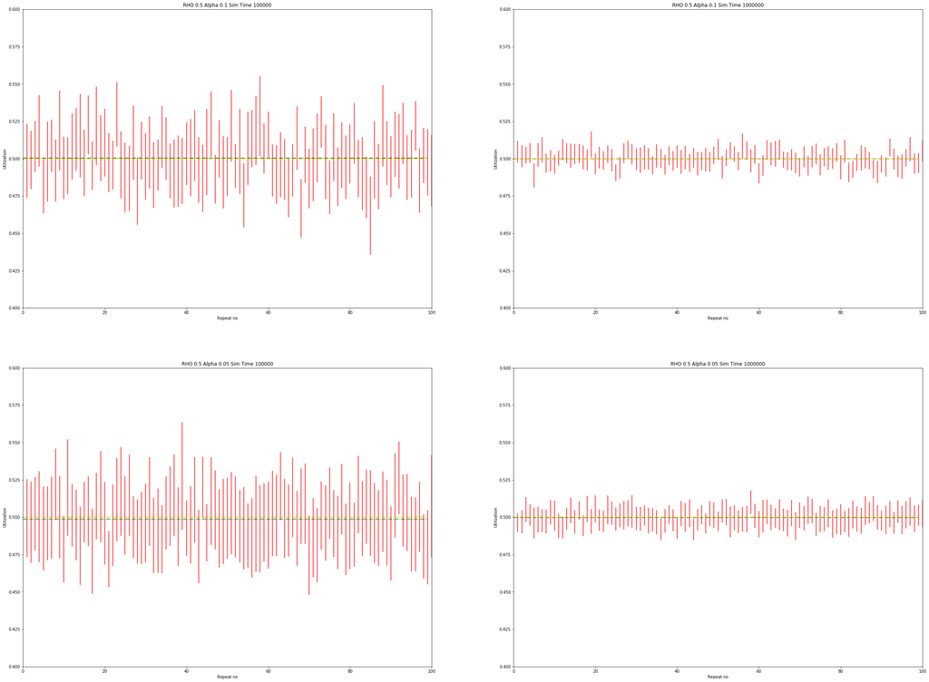

```
 Sim time 100.0s  Alpha 0.1 RHO 0.9
 Sim time 1000.0s  Alpha 0.1 RHO 0.9
 Sim time 100.0s  Alpha 0.05 RHO 0.9
 Sim time 1000.0s  Alpha 0.05 RHO 0.9
```

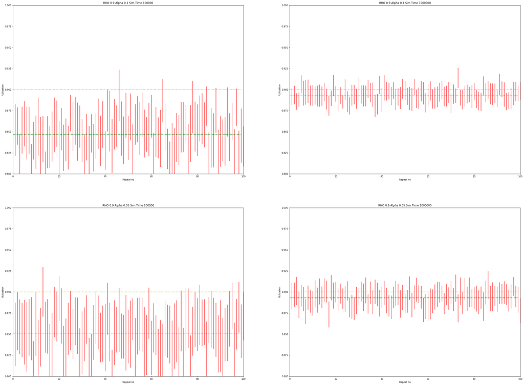

```python
part5_simstudy.task_5_2_4()
```

### 5.3 Analysis and General Questions

#### Task 5.3.2: Confidence Interval Width

```python
p = 0.9
S = 4.0
bp = ((1-p)*(p**(S+1)))/(1-(p**(S+2)))
print (bp)
```

```
0.1260225499883686
```

- The analytic result is 0.1260 as can be seen above calculation. The main reason of such differences is the transient phase of the simulation. This can be easily seen if we compare the 100s and 1000s simulations in the task_5_2_1(). 1000s simulation result is much close to the actually blocking probablity since the transient effect can be tolerated during the simulation.
- There is not that much differences between 100 and 1000 batch sizes but 1000 batch size is more near to actually probability. Because if we get 100 batch size than we can have more samples from the transient phase which make it diffucult compensate during simulation.

#### Task 5.3.3: Confidence Interval Width

- The values written on the graph may not be clear to read, but it follows the rule of printing values as written above the plots. Observations;
- Confidence interval is larger for small simulation time(e.g. 100s)
- Alpha value is important to understand how many of the red lines cover the actual utilization value.
- In the longer simulations, the difference between actual rho and observed rho become lower.
- For the Rho = 0.9, observed rho value is different(lower) than the actuall rho value. This effect can be seen especially for lower simulation time.

#### Task 5.3.4: Variable Simulation Time

- I think, it would not be possible because we need to consider the all the events. If we take samples only when a packet is dropped then this would not show all the characteristic of the simulation.

#### Task 5.3.5: Bootstrapping

- If the number of samples are small, then bootstrap method can be used to resample the same data multiple times and treating the sample as an approximation of the true distribution of data.
- If we know the distribution of the samples are from true distribution, then they might become the same.